# Assignment 2 - New York Taxi Data

Anahita Asharchi

## Specifications of this assignment:

Using the data from week 2 of January 2016, construct a model that predicts the amount of a tip. Evaluate the mean squared error of this model on the data from week 4 of January 2016. Write a report that describes how you constructed the model and how accurate it is.

```r
library(tidyverse)
#training week 2
taxi<- read_csv("week2.csv")
taxi %>% summary()
```

```
##     VendorID     tpep_pickup_datetime
##  Min.   :1.000   Min.   :2016-01-08 00:00:00
##  1st Qu.:1.000   1st Qu.:2016-01-09 18:02:05
##  Median :2.000   Median :2016-01-11 15:19:10
##  Mean   :1.532   Mean   :2016-01-11 14:11:04
##  3rd Qu.:2.000   3rd Qu.:2016-01-13 11:35:15
##  Max.   :2.000   Max.   :2016-01-14 23:59:59
##  tpep_dropoff_datetime         passenger_count trip_distance
##  Min.   :2016-01-08 00:01:23   Min.   :0.000   Min.   :  0.000
##  1st Qu.:2016-01-09 18:16:14   1st Qu.:1.000   1st Qu.:  1.000
##  Median :2016-01-11 15:33:52   Median :1.000   Median :  1.630
##  Mean   :2016-01-11 14:25:25   Mean   :1.659   Mean   :  2.809
##  3rd Qu.:2016-01-13 11:50:25   3rd Qu.:2.000   3rd Qu.:  3.000
##  Max.   :2016-01-15 23:39:18   Max.   :9.000   Max.   :502.200
##  pickup_longitude  pickup_latitude   RatecodeID     store_and_fwd_flag
##  Min.   :-121.93   Min.   : 0.00   Min.   : 1.000   Length:2651287
##  1st Qu.: -73.99   1st Qu.:40.74   1st Qu.: 1.000   Class :character
##  Median : -73.98   Median :40.75   Median : 1.000   Mode  :character
##  Mean   : -72.84   Mean   :40.13   Mean   : 1.036
##  3rd Qu.: -73.97   3rd Qu.:40.77   3rd Qu.: 1.000
##  Max.   :   0.00   Max.   :46.31   Max.   :99.000
##  dropoff_longitude dropoff_latitude  payment_type    fare_amount
##  Min.   :-121.93   Min.   : 0.00    Min.   :1.000   Min.   :-957.60
##  1st Qu.: -73.99   1st Qu.:40.74    1st Qu.:1.000   1st Qu.:   6.50
##  Median : -73.98   Median :40.75    Median :1.000   Median :   9.00
##  Mean   : -72.91   Mean   :40.17    Mean   :1.337   Mean   :  12.06
##  3rd Qu.: -73.96   3rd Qu.:40.77    3rd Qu.:2.000   3rd Qu.:  13.50
##  Max.   :   0.00   Max.   :52.75    Max.   :4.000   Max.   :3039.00
##      extra             mta_tax          tip_amount
##  Min.   :-35.6400   Min.   :-0.5000   Min.   :-220.800
##  1st Qu.:  0.0000   1st Qu.: 0.5000   1st Qu.:   0.000
##  Median :  0.0000   Median : 0.5000   Median :   1.320
##  Mean   :  0.3235   Mean   : 0.4978   Mean   :   1.728
##  3rd Qu.:  0.5000   3rd Qu.: 0.5000   3rd Qu.:   2.260
##  Max.   :  4.1000   Max.   :36.4400   Max.   : 900.000
##   tolls_amount      improvement_surcharge  total_amount
##  Min.   :-12.5000   Min.   :-0.3000       Min.   :-958.40
##  1st Qu.:  0.0000   1st Qu.: 0.3000       1st Qu.:   8.30
##  Median :  0.0000   Median : 0.3000       Median :  11.30
##  Mean   :  0.2746   Mean   : 0.2998       Mean   :  15.18
##  3rd Qu.:  0.0000   3rd Qu.: 0.3000       3rd Qu.:  16.56
##  Max.   :811.0000   Max.   : 0.3000       Max.   :3045.34
```

```r
#Loading in packages
library(lubridate)
```

```r
library(ggplot2)
library(leaps)
```

### Sample for faster plotting

```r
#sampling data for faster plots
set.seed(520737112)
numrow <- nrow(taxi)
mysample <- sample(nrow(taxi),0.10*numrow)
taxi_sample <- taxi[mysample,]
```

We are taking a sample of size 10% of our original data. This is for faster plotting, we will use this for some of our later plots.

# Cleaning Our Data

##### VENDORID

```r
unique(taxi$VendorID)
```

```
## [1] 2 1
```

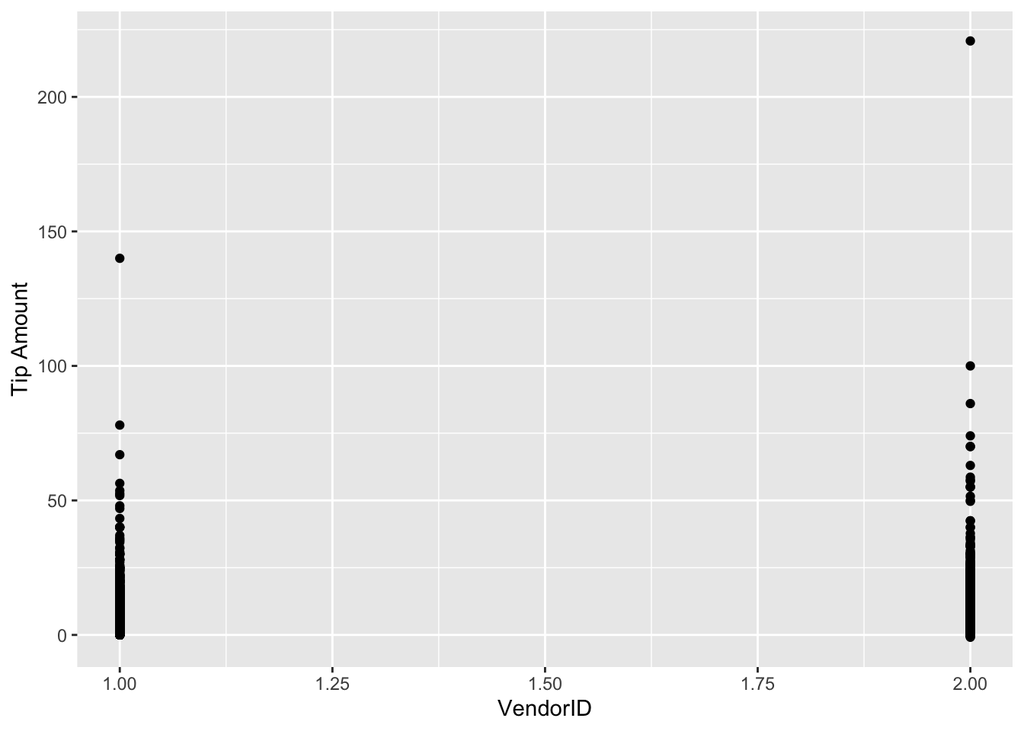

```r
taxi_sample %>% ggplot(aes(VendorID, tip_amount)) + geom_point() + ylab("Tip Amount")
```

We can see that VendorID does not need further cleaning, as it has 2 variables. In our data dictionary we are told that it should only have two variables. We can also say that VendorID does not have an affect on the tip amount, as seen by vendor 1 and 2’s spread of tip amounts being relatively similar.

##### PASSENGER COUNT

```r
taxi %>%
  group_by(passenger_count) %>%
  tally()
```

```
## # A tibble: 10 x 2
##    passenger_count       n
##              <dbl>   <int>
##  1               0     148
##  2               1 1896000
##  3               2  370693
##  4               3  101968
##  5               4   47979
##  6               5  144695
##  7               6   89793
##  8               7       4
##  9               8       5
## 10               9       2
```

```r
taxi <- taxi %>% filter(passenger_count > 0 & passenger_count < 7)
```

Majourity of our trips appear to have 6 or less passengers, which makes common sense since most cars have a maximum capacity of 7 seats. Also we can see passenger count at 0, a taxi should have atleast one passenger in it for it to be counted as a trip.

Thus, we have filtered our passenger count to being between 1 - 6.

##### RATECODEID

```r
taxi %>% group_by(RatecodeID) %>% tally()
```

```
## # A tibble: 7 x 2
##   RatecodeID       n
##        <dbl>   <int>
## 1          1 2589429
## 2          2   49557
## 3          3    3587
## 4          4    1022
## 5          5    7464
## 6          6      24
## 7         99      45
```

```r
taxi <- filter(taxi, RatecodeID < 7)
```

We can see above a given rate code at 99, which is not given in our given documentation so we have removed it from our data.

##### TIP AMOUNT

```r
taxi %>%
  mutate(tip_amount=cut(taxi$tip_amount,10)) %>%
  group_by(tip_amount) %>%
  tally()
```

```
## # A tibble: 8 x 2
##   tip_amount        n
##   <fct>         <int>
## 1 (-222,-109]       1
## 2 (-109,3.36] 2317121
## 3 (3.36,115]   333932
## 4 (115,228]        19
## 5 (228,340]         7
## 6 (340,452]         1
## 7 (452,564]         1
## 8 (788,901]         1
```

```r
taxi <- taxi %>% filter(tip_amount<350 && tip_amount >=0)
```

From the above it can be said that we can filter our tip amount to being under 350 dollars. Our tip amount should also be greater or equal to zero for our data to make sense in further analysis.

##### FARE AMOUNT

```r
taxi <- taxi %>% filter(fare_amount >= 2.5) #google search for min taxi rate
```

Above we are filtering fare amount to be the greater or equal to the minimum taxi rate in New York city, (minimum amount found through google search).

##### IMPROVEMENT SURCHARGE

```r
taxi %>% group_by(improvement_surcharge) %>% summarise(n())
```

```
## # A tibble: 5 x 2
##   improvement_surcharge   `n()`
##                   <dbl>   <int>
## 1                  0        169
## 2                  0.1        3
## 3                  0.16       1
## 4                  0.25       1
## 5                  0.3  2648975
```

```r
taxi <- taxi %>%
  mutate(improvement_surcharge=ifelse(improvement_surcharge > 0.3, 0.3, improvement_surcharge)) %>%
  mutate(improvement_surcharge=ifelse(improvement_surcharge < 0, 0, improvement_surcharge))
```

##### TOLL AMOUNT

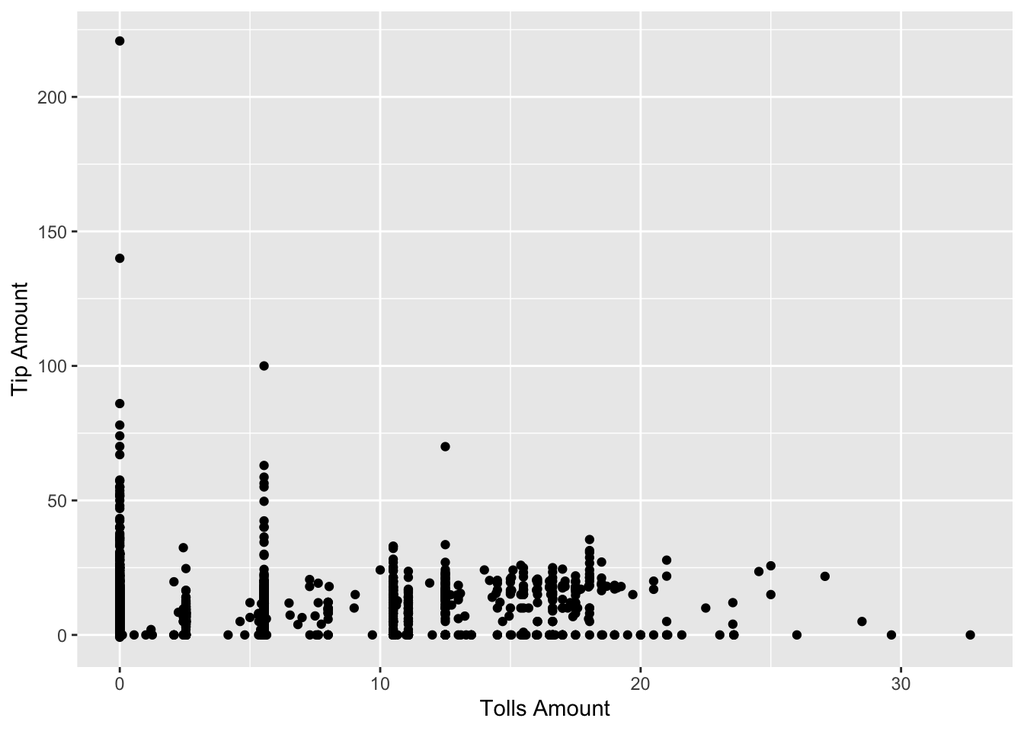

```r
taxi <- taxi %>% filter(tolls_amount >= 0)
taxi_sample %>% ggplot(aes(tolls_amount, tip_amount)) + geom_point() + ylab("Tip Amount") + xlab("Tolls Amount")
```

##### USEFUL DATA

```r
taxi <- taxi %>%
  mutate(dropoff_datetime = tpep_dropoff_datetime,
         pickup_datetime = tpep_pickup_datetime,
         dow = wday(pickup_datetime,label=TRUE,abbr=TRUE, week_start = 1),
         hour_trip_start = factor(hour(pickup_datetime)),
         trip_duration =     as.numeric(difftime(dropoff_datetime,pickup_datetime,units="mins")),
         payment_type_label = fct_recode(factor(payment_type),
                                         "Credit Card"="1",
                                         "Cash"="2",
                                         "No Charge"="3",
                                         "Other"="4"))  %>%

  select(-total_amount, -tpep_dropoff_datetime, -tpep_pickup_datetime)
```

Above we are creating a few new columns which will be handy later on in our analysis and removing any unuseful columns.

### Further cleaning/filtering

##### TRIP DURATION

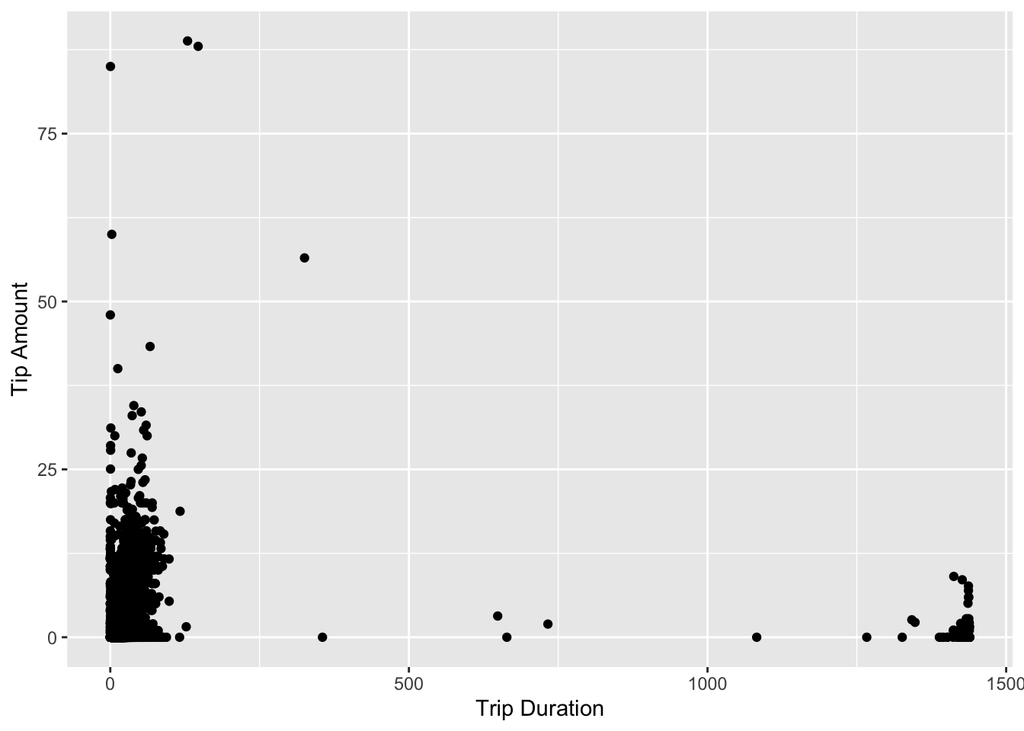

```r
taxi %>% sample_n(50000) %>% ggplot(aes(trip_duration,tip_amount)) + geom_point() + ylab("Tip Amount") + xlab("Trip Duration")
```

```r
taxi <- taxi %>% filter(trip_duration < 120, trip_duration>0)
```

Above you can see that during most of the time, as trip duration increases the tip amount is decreasing suggesting that trip duration does have an effect on tip amount. We have filtered our data further to trip duration values being less than 120 and greater than 0.

##### PAYMENT TYPE LABEL

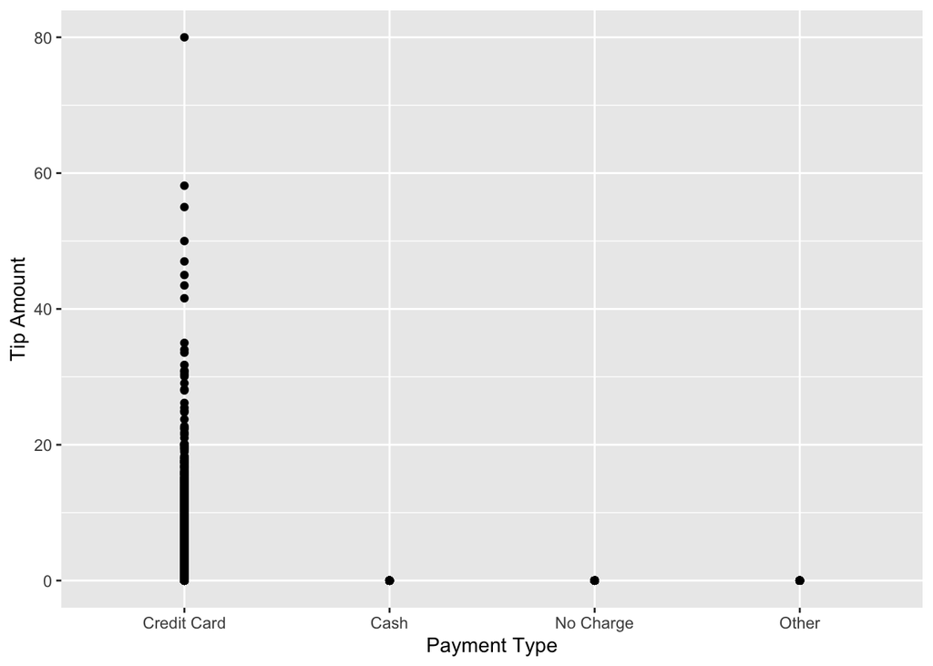

```r
taxi %>% sample_n(50000) %>% ggplot(aes(payment_type_label, tip_amount)) + geom_point() + xlab("Payment Type") + ylab("Tip Amount")
```

```r
taxi <- taxi %>% filter(payment_type_label == "Credit Card")
```

We can see above, that the only form of payment that also includes tipping is credit card, so we have filtered out our other forms of payment as they will be of no use for predicting tip amount.

##### HOUR TRIP STARTS

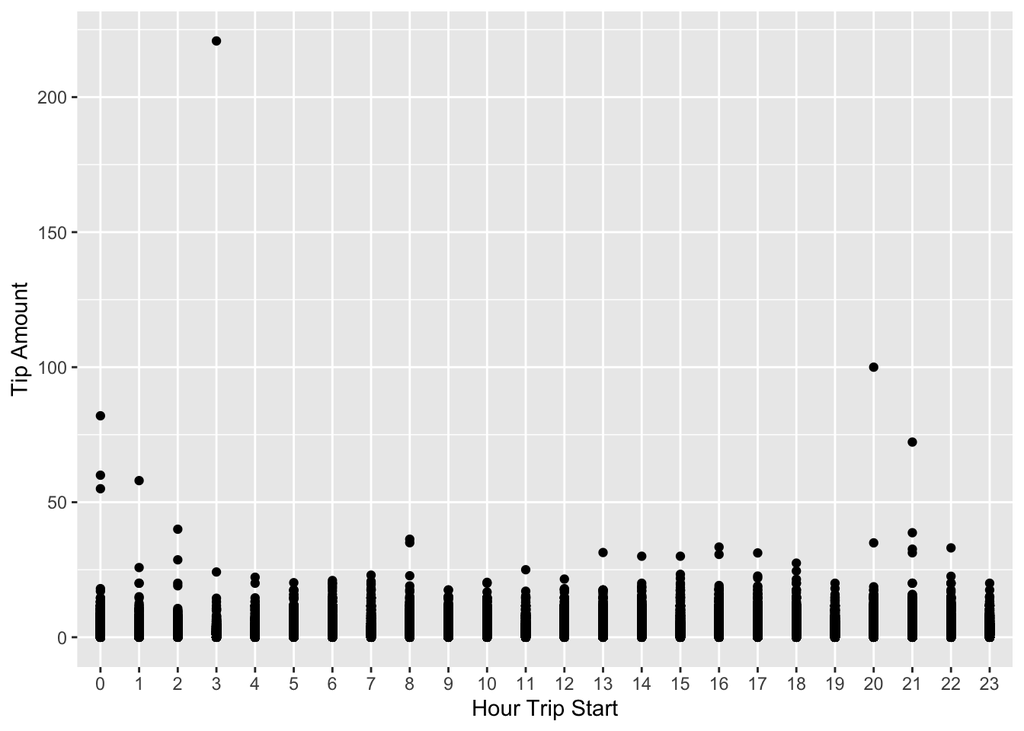

```r
taxi %>% sample_n(50000) %>%
  ggplot(aes(x=hour_trip_start, y = tip_amount)) + geom_point() + xlab("Hour Trip Start") + ylab("Tip Amount")
```

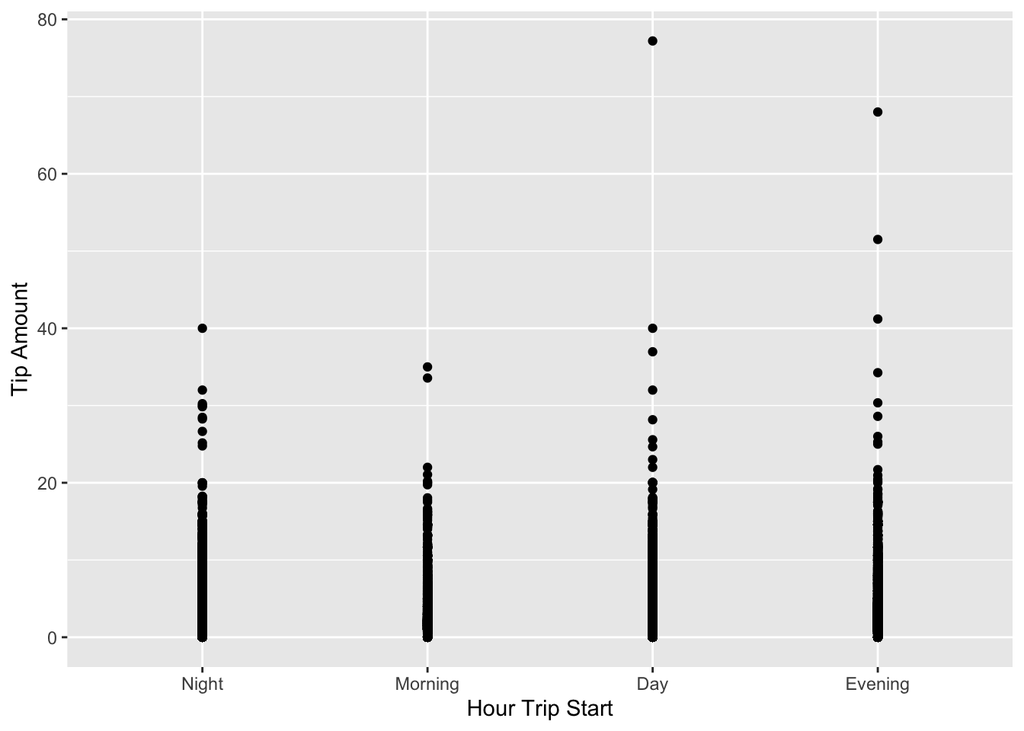

```r
#Further reducing down the tip amount
taxi <- taxi %>%  filter(tip_amount < 100)

taxi <- taxi %>% na.omit() %>%  mutate(hours = fct_collapse(hour_trip_start, Morning = c("1", "2", "3", "4", "5", "6"), Day =  c("7", "8", "9", "10", "11", "12"), Evening = c("13", "14", "15", "16", "17", "18"), Night = c("19","20", "21", "22", "23", "0")))

taxi %>% sample_n(50000) %>% ggplot(aes(x=hours, y = tip_amount)) + geom_point() + xlab("Hour Trip Start") + ylab("Tip Amount")
```

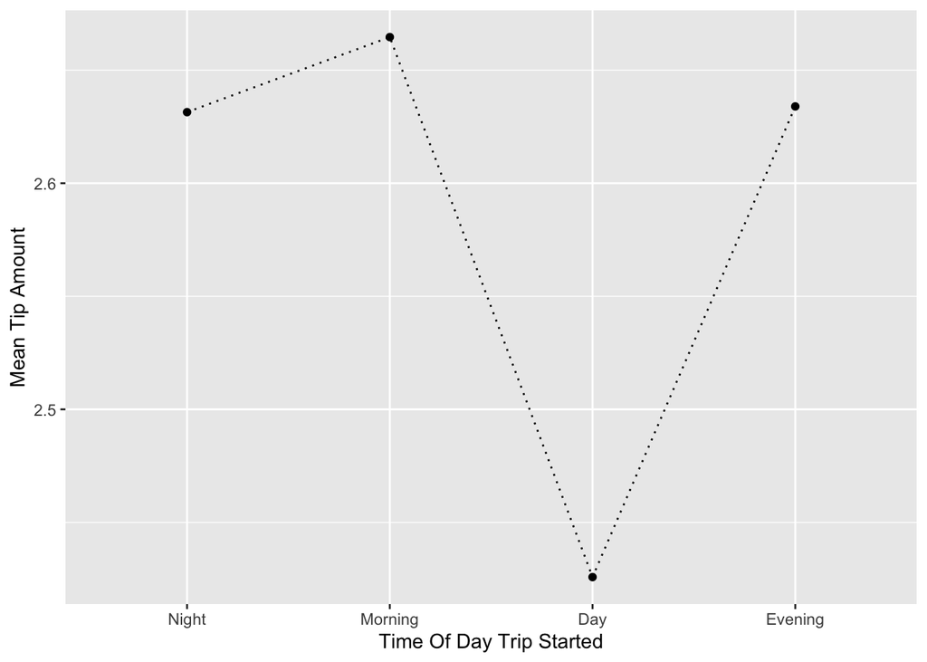

```r
taxi %>% select(hours, tip_amount) %>% group_by(hours) %>%
  summarize(mean = mean(tip_amount)) %>%
  ggplot(aes(x=hours,y=mean)) +  geom_point() +
  geom_line(aes(group=1),linetype='dotted') + ylab("Mean Tip Amount") + xlab("Time Of Day Trip Started")
```

From our tip amount and hour trip start plot, we can see apparent patterns between different times in the day so we have further categorized our data into “Morning” “Night” “Morning” “Day” and “Evening”.

From our time of day trip started vs mean tip amount graph, we can see that our mean tip amount is fairly similar for night, morning and evening. We can aslo see that our mean tip amount is at its lowest during the day. This suggest that the “hours” do affect mean tip amount.

##### DOW

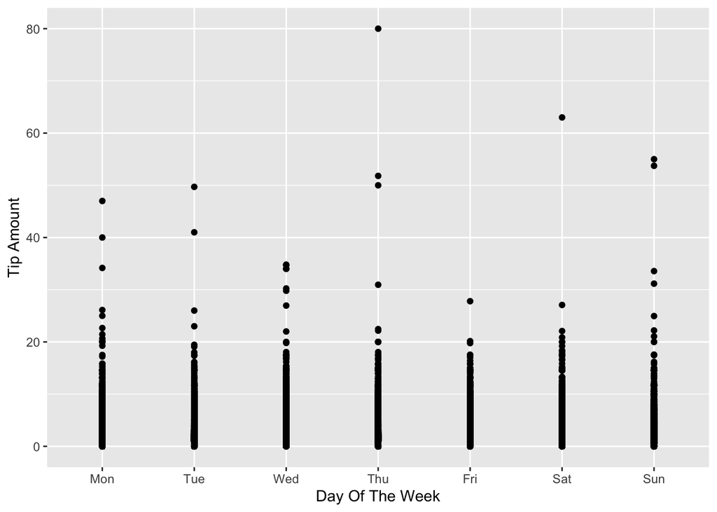

```r
taxi %>% sample_n(50000) %>% ggplot(aes(x=dow,y = tip_amount)) + geom_point() + ylab("Tip Amount") + xlab("Day Of The Week")
```

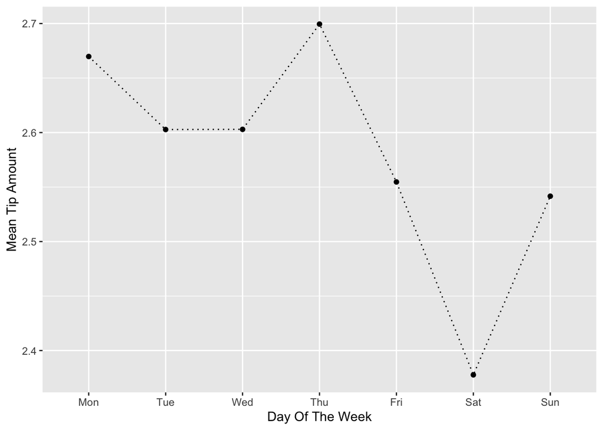

```r
taxi %>%
  group_by(dow) %>%
  summarize(mean = mean(tip_amount)) %>%
  ggplot(aes(x=dow,y=mean)) +  geom_point() +
  geom_line(aes(group=1),linetype='dotted') + ylab("Mean Tip Amount") + xlab("Day Of The Week")
```

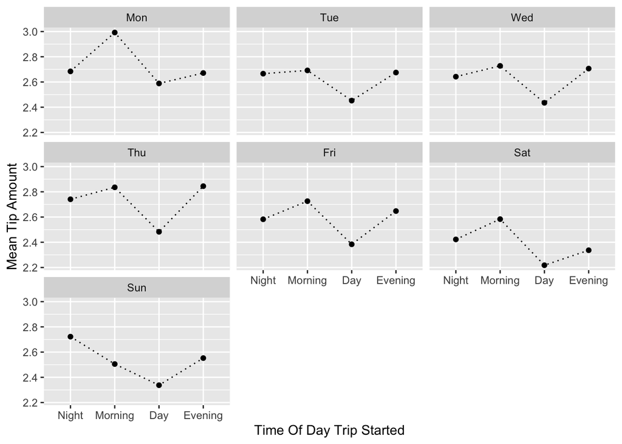

```r
taxi %>%
  group_by(dow,hours) %>%
  summarize(mean_tip = mean(tip_amount)) %>%
  ggplot(aes(x=hours,y=mean_tip)) +  geom_point() +
  facet_wrap(~dow) +geom_line(aes(group=1),linetype='dotted') + ylab("Mean Tip Amount") + xlab("Time Of Day Trip Started")
```

Above we can see from our analysis that the medium tip amount appears to show quite a similar pattern for weekdays, and also are fairly similar pattern for weekends. Thus, we will further factor the days of the week into weekday and weekend.

##### WEEKEND/WEEKDAY

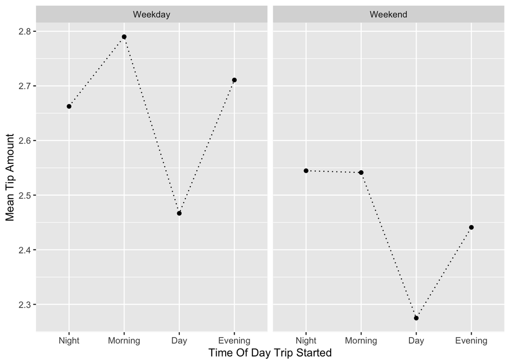

```r
taxi <- taxi %>% na.omit() %>%  mutate(dow = fct_collapse(dow,  Weekday = c("Mon", "Tue", "Wed", "Thu", "Fri"), Weekend = c("Sat", "Sun")))

taxi %>%
  group_by(dow,hours) %>%
  summarize(mean_tip = mean(tip_amount)) %>%
  ggplot(aes(x=hours,y=mean_tip)) +  geom_point() +
  facet_wrap(~dow) +geom_line(aes(group=1),linetype='dotted') + ylab("Mean Tip Amount") + xlab("Time Of Day Trip Started")
```

We can now conclude that our time of the day and whether it is a weekend or a weekday both affect our mean tip amount and should be used for our later regression.

##### COORDINATES NY

```r
taxi <- taxi %>%
  filter(dropoff_longitude > -74.15 & dropoff_longitude < -73.7004) %>%
  filter(pickup_longitude > -74.15 & pickup_longitude < -73.7004) %>%
  filter(dropoff_latitude < 40.9176 & dropoff_latitude > 40.5774) %>%
  filter(pickup_latitude < 40.9176 & pickup_latitude > 40.5774)
```

We have filtered the data so our coordinates lie within the New York region.

##### PLOT OF COORDINATES

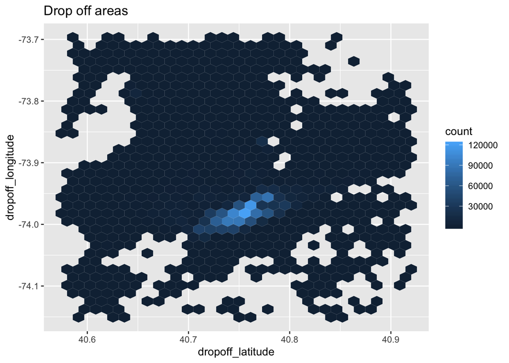

```r
library(hexbin)
taxi %>%
  ggplot(aes(dropoff_latitude,dropoff_longitude)) + geom_hex() + labs(title="Drop off areas")
```

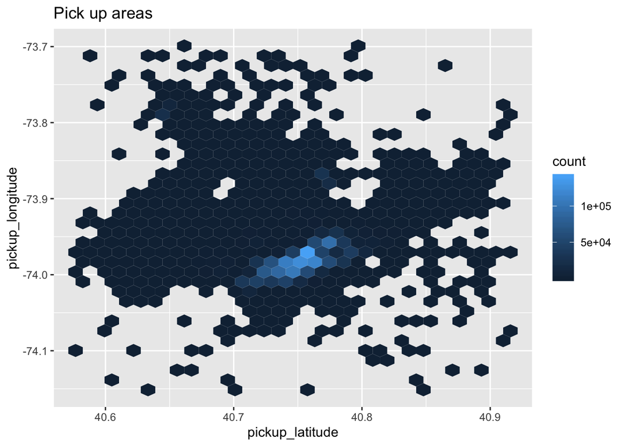

```r
taxi %>%
  ggplot(aes(pickup_latitude,pickup_longitude)) + geom_hex() + labs(title="Pick up areas")
```

Hotspot 1 - Latitude 40.7 to 40.8, longitude -74.05 to -73.93 Hotspot 2 - Latitude 40.75 to 40.8, longitude -73.85 to -73.9

High drop off and pick up rates are also expected at JFK airport. Using google we revealed that the John F Kennedy airport is located at latitude 40.64 and longitude -73.78. This is shown on our graph in the mild colour change regions, at approximately: Latitude 40.63 to 40.67 Longitude -73.76 to -73.8

##### HOTSPOT1,HOTSPOT2,AIRPORT,OTHER

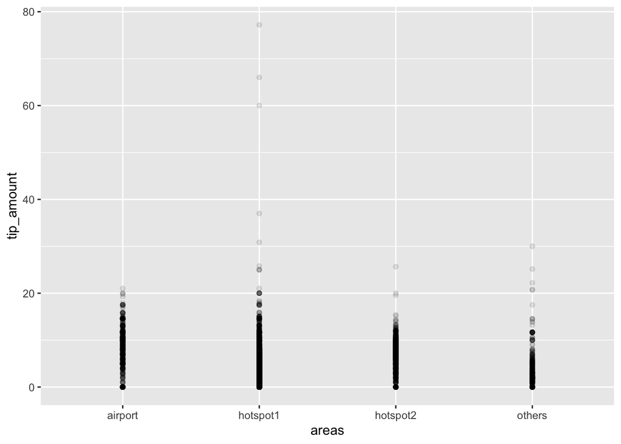

```r
taxi<- taxi %>%
mutate(areas = case_when(pickup_latitude >= 40.68 & pickup_latitude <= 40.83 & pickup_longitude >= -74.05 & pickup_longitude <=                                   -73.93 ~ "hotspot1",
                              pickup_latitude >= 40.75 & pickup_latitude <= 40.8 & pickup_longitude >= -73.9 & pickup_longitude <= -73.85                               ~ "hotspot2",
                              pickup_latitude > 40.63 & pickup_latitude<40.67 &
                               pickup_longitude > -73.8 & pickup_longitude < -73.76 ~ "airport",
                             dropoff_latitude > 40.63 & dropoff_latitude<40.67 &
                               dropoff_longitude > -73.8 & dropoff_longitude < -73.76 ~ "airport",
                              TRUE ~ "others"))


taxi %>% sample_n(50000) %>% ggplot(aes(x=areas,y= tip_amount)) + geom_point(alpha=0.1)
```

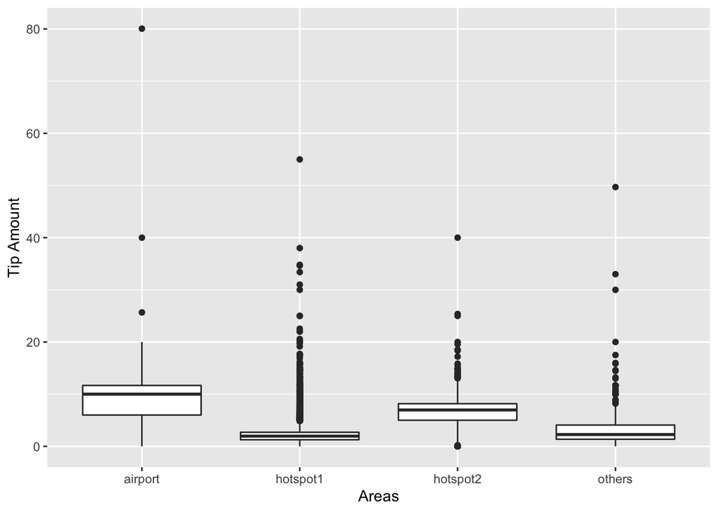

```r
taxi %>% sample_n(50000) %>% ggplot(aes(areas,tip_amount))+ geom_boxplot() + ylab("Tip Amount") + xlab("Areas")
```

We will be using “areas” in later regression, to investigate whether or not this variable truly has an affect on our tip amount.

##### Further reduction - more unwanted columns

```r
taxi <- taxi %>% select(-VendorID, -pickup_longitude, -pickup_latitude, -RatecodeID, -store_and_fwd_flag, -dropoff_longitude, -dropoff_latitude, -extra, -mta_tax, -dropoff_datetime, -hour_trip_start, -improvement_surcharge, -pickup_datetime,-payment_type_label,-payment_type,-fare_amount)
```

# CROSS-VALIDATION AND TUNING MODEL SELECTION

##### Separation into training and testing sets

```r
taxi_sample <- sample.int(n = nrow(taxi), size=500000, replace = F)
train_x <- taxi[taxi_sample, ]
train_y <- train_x$tip_amount
test_x  <- taxi[-taxi_sample, ] %>% sample_n(200000)
test_y <- test_x$tip_amount
mf<-model.frame(tip_amount~.+dow:hours, data=train_x)
#Model matrix with all relavent variables and interactions betweem all.
train_X<-model.matrix(tip_amount~.+dow:hours, mf)[,-1]
```

##### AIC calculations: lambda tuning

```r
c("nvmax" = ncol(train_X))
```

```
## nvmax
##    14
```

```r
allyhat<-function(xtrain, ytrain, xtest,lambdas,nvmax=14){
  n<-nrow(xtrain)
  yhat<-matrix(nrow=nrow(xtest),ncol=length(lambdas))
  search<-regsubsets(xtrain,ytrain, nvmax=nvmax, method="back")
  summ<-summary(search)
  for(i in 1:length(lambdas)){
    penMSE<- n*log(summ$rss)+lambdas[i]*(1:nvmax)
    best<-which.min(penMSE)  #lowest AIC
    betahat<-coef(search, best) #coefficients
    xinmodel<-cbind(1,xtest)[,summ$which[best,]] #predictors in that model
    yhat[,i]<-xinmodel%*%betahat
  }
  yhat
}

n<-nrow(train_X)
folds<-sample(rep(1:10,length.out=n))
lambdas<-c(2,4,6,8,10,12)
fitted<-matrix(nrow=n,ncol=length(lambdas))
for(k in 1:10){
  train<- (1:n)[folds!=k]
  test<-(1:n)[folds==k]
  fitted[test,]<-allyhat(train_X[train,],train_y[train],train_X[test,],lambdas)
}
colMeans((train_y-fitted)^2)
```

```
## [1] 1.837385 1.837364 1.837364 1.837388 1.837435 1.837490
```

MSPE for all different lambda’s are the same, so we cannot tune lambda values. Instead we will try it with parameters.

##### Tuning the number of variables - “p”

```r
set.seed(520737112)
#Training data used in regsubsets.
#finding best 51 variable model.
search = regsubsets(train_X, train_y, nvmax =14, method = "backward")

#Test data used for MSPE.
mf1<-model.frame(tip_amount~.+dow:hours, data=test_x)
test_X<-model.matrix(tip_amount~.+dow:hours ,mf1)[,-1]

MSPE = numeric(14)
for (p in 1:14){
  betahat<-coef(search, p)
  xinmodel<-cbind(1,test_X)[,summary(search)$which[p,]]
  yhat1<-xinmodel%*%betahat
  MSPE[p]<-mean( (test_y-yhat1)^2)
  }

min_mspe <- which.min(MSPE)
c("MSPE"= min_mspe)
```

```
## MSPE
##   14
```

```r
MSPE[min_mspe]
```

```
## [1] 1.993987
```

Our MSPE is giving us the MSPE for each number of predictors. The minimum MSPE belongs to our model with 14 variables. Next we want to extract our coefficients “betahats” for our model with 14 variables.

```r
betahat <- coef(search, min_mspe)
betahat
```

```
##        (Intercept)    passenger_count      trip_distance
##       0.8341075979      -0.0009410083       0.3295501298
##       tolls_amount              dow.L      trip_duration
##       0.2813694923      -0.0689566737       0.0508928044
##       hoursMorning           hoursDay       hoursEvening
##      -0.0763160452      -0.0720935559      -0.0246729942
##      areashotspot1      areashotspot2        areasothers
##       0.0088909338       0.3657460254       0.3691696460
## dow.L:hoursMorning     dow.L:hoursDay dow.L:hoursEvening
##       0.0402816549       0.0356717124      -0.0310109861
```

The above is our model, with the lowest MSPE.

##### Assessing our accuracy with week 4 taxi data

```r
week4 <- read_csv("week4.csv")
```

```r
week4 <- week4 %>%
  mutate(dow = wday(tpep_pickup_datetime,label=TRUE,abbr=TRUE, week_start = 1),
         hour_trip_start = factor(hour(tpep_pickup_datetime)),
         trip_duration = as.numeric(difftime(tpep_dropoff_datetime,tpep_pickup_datetime,units="mins")),          payment_type_label = fct_recode(factor(payment_type),
                                         "Credit Card"="1",
                                         "Cash"="2",
                                         "No Charge"="3",
                                         "Other"="4")) %>% select(-total_amount, -tpep_dropoff_datetime, -tpep_pickup_datetime)
```

##### DOW,HOURS

```r
week4 <- week4 %>%  mutate(hours = fct_collapse(hour_trip_start, Morning = c("1", "2", "3", "4", "5", "6"), Day =  c("7", "8", "9", "10", "11", "12"), Evening = c("13", "14", "15", "16", "17", "18"), Night = c("19","20", "21", "22", "23", "0")))

week4 <- week4 %>% na.omit() %>%  mutate(dow = fct_collapse(dow,  Weekday = c("Mon", "Tue", "Wed", "Thu", "Fri"), Weekend = c("Sat", "Sun")))
```

##### LONG/LAT

```r
week4 <- week4 %>%
  filter(dropoff_longitude > -74.15 & dropoff_longitude < -73.7004) %>%
  filter(pickup_longitude > -74.15 & pickup_longitude < -73.7004) %>%
  filter(dropoff_latitude < 40.9176 & dropoff_latitude > 40.5774) %>%
  filter(pickup_latitude < 40.9176 & pickup_latitude > 40.5774)

week4 <- week4 %>%
  mutate(areas = case_when(pickup_latitude >= 40.68 & pickup_latitude <= 40.83 & pickup_longitude >= -74.05 & pickup_longitude <=                                   -73.93 ~ "hotspot1",
                              pickup_latitude >= 40.75 & pickup_latitude <= 40.8 & pickup_longitude >= -73.9 & pickup_longitude <= -73.85                               ~ "hotspot2",
                              pickup_latitude > 40.63 & pickup_latitude<40.67 &
                               pickup_longitude > -73.8 & pickup_longitude < -73.76 ~ "airport",
                             dropoff_latitude > 40.63 & dropoff_latitude<40.67 &
                               dropoff_longitude > -73.8 & dropoff_longitude < -73.76 ~ "airport",
                              TRUE ~ "others"))
```

##### FINAL REDUCTION

```r
#final reduction
week4 <- week4 %>% select(-VendorID, -pickup_longitude, -pickup_latitude, -RatecodeID,-store_and_fwd_flag, -dropoff_longitude, -dropoff_latitude, -payment_type, -fare_amount, -extra, -mta_tax,-hour_trip_start,-payment_type_label)
week4 <- week4 %>% select(-improvement_surcharge)
```

```r
set.seed(520737112)
week4 <- week4 %>% sample_n(500000)
week4_y <- week4$tip_amount
mf2<-model.frame(tip_amount~.+dow:hours, data=week4)
week4_x<-model.matrix(tip_amount~.+dow:hours, mf2)[,-1]
```

```r
Xpred = cbind(1, week4_x)[,summary(search)$which[min_mspe,]]
yhat2<- Xpred%*%betahat
MSPE <- mean((week4_y-yhat2)^2)
```

```r
c("MSPE week 4" = MSPE)
```

```
## MSPE week 4
##    12.31801
```

```r
c("sqrt MSPE week 4" = sqrt(MSPE))
```

```
## sqrt MSPE week 4
##         3.509703
```

```r
c("Variance week 4" = var(week4$tip_amount))
```

```
## Variance week 4
##        6.368398
```

```r
c("Standard Deviation week4" = sd(week4$tip_amount))
```

```
## Standard Deviation week4
##                 2.523568
```